# Diagonal Case

## 7.6 Comparing the results of the fits

### 7.6.1 Estimates of abundance

Comparing estimates of abundance among fit

| Source | Mean | SD |
| --- | --- | --- |
| No covariates | 610227 | 103992 |
| Default prior | 601688 | 74420 |
| Weak prior | 612352 | 65280 |
| Strong prior | 636210 | 94309 |

There appears to be little impact on the estimate of abundance, but notice that the uncertainty declines as you add information from *fit1* to *fit3(), but when you add a strong conflicting prior (see below), the uncertainty now increases.

### 7.6.2 Estimates of coefficients

Comparing estimates of beta coefficients among fit

| Source | Estimate | Mean | SD |
| --- | --- | --- | --- |
| No covariates | Intercept | -4.469 | 0.514 |
| Default prior | Intercept | 0.761 | 2.490 |
| Default prior | Slope | -0.636 | 0.297 |
| Weak prior | Intercept | 3.069 | 1.130 |
| Weak prior | Slope | -0.912 | 0.140 |
| Strong prior | Intercept | 0.300 | 0.010 |
| Strong prior | Slope | -0.697 | 0.010 |

### 7.6.3 Comparing the residual standard deviation around the line of fit

Comparing estimates of residual variation in logitP among fit

| Source | Mean | SD |
| --- | --- | --- |
| No covariates | 1.382 | 0.448 |
| Default prior | 0.572 | 0.473 |
| Weak prior | 0.242 | 0.207 |
| Strong prior | 1.270 | 0.409 |

The residual variation declines as more information is added via the prior for the first 3 fits, but then increases when a strong (conflicting) prior is added (last fit).

### 7.6.4 Comparing the fits

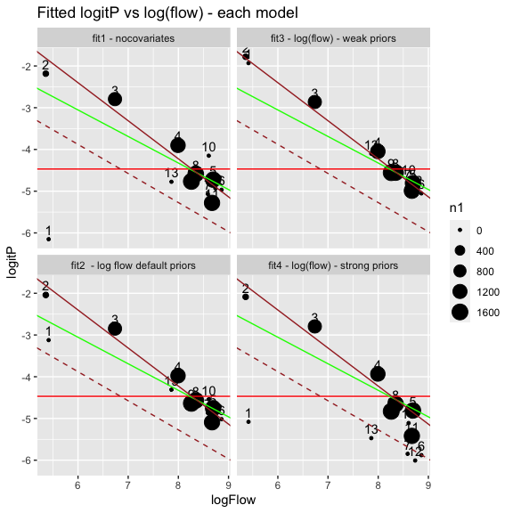

All fits: logitP vs log(flow)

In the plots of *logitP* vs. *log(flow)*, the red horizontal line is from *fit1* (no covariates) and represents the mean. The green line is from the fit of *logitP* vs *logFlow* using the default prior. The solid brown line is from the fit of *logitP* vs *logFlow* for the weak prior and the dashed brown line is for the strong prior. The size of the dots represents n1 the number of fish released.

So for *fit1*, there is very little data for time 1 and time 2, and and so their *logitP* are basically free to vary. For *fit2*, the default prior gives some (but not much information) about the relationship between *logitP* and *logFlow*, so the estimates of *logitP* for periods 1 and 2 are moved “closer” to the green line. For *fit3*, the weak prior gives more information and so the points move very close to the line. As well, the periods with lots of data can be well fit with very little noise and so the model says the the noise of periods in *logitP* must also be small, and so all the points are forced to lie on the line. For *fit4*, the very strong prior is placed on a WRONG line (the dashed brown). Now the model is in a quandary and says that the only way the *logitP* for weeks 3, 4, etc. with lots of data are consistent with the dashed brown line is if the among period variance is very large and so the *logitP* for weeks with very poor data are allowed to move away from the brown dashed line.

We can also compare the spline fit to the number of unmarked fish:

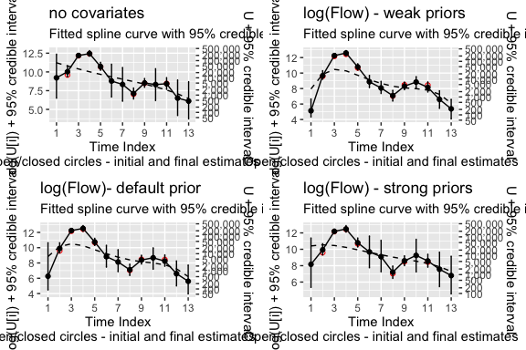

Allfts: spline fit to U

The spline is only affected slightly.

We can also compare the trend of *logitP* over time:

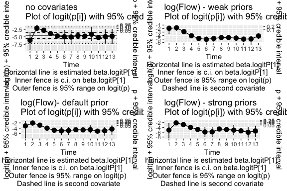

All fits: logitP vs time

The trend over time is mostly unchanged for period with lots of data, and for periods with very small amount of data, the points are allowed to vary as needed.